# Analysis to determine factors that are important in order to know if a patient will show up for their scheduled appointment

## INTRODUCTION

The No show appointments dataset contains 110527 observations about patients who kept to their appointments and those who missed out on their appointments. The purpose of this collection is to determine the factors that are important to determine patients who are likely to keep to their appointments. The gender, age, health status, health scholarship status and the hospital neighbourhood of the patients are provided in the dataset.

The availabe information in the dataset will enable us to answer questions like:

1. Does the gender of a patient determine if a patient will show up or not?
2. Does the age group of a patient correlate with whether or not a patient keeps to his/her appointment
3. How does the underlying health status of the patient affect show up?
4. Does it matter if a patient is on scholarship or not?
5. If recieving a reminder sms help a patient keep to appointments
6. If the number of days between scheduling and the appointment days is a determining factor.
7. Does the location of the hospital determine if a patient will show up?

During this analysis, I will be trying to answer all the questions listed above.

## Importing libraries for analysis

```python
import pandas as pd
import numpy as np
import matplotlib.pyplot as plt
import seaborn as sns
import datetime
from datetime import datetime
```

## Loading our dataset

```python
df = pd.read_csv('noshowappointments-kagglev2-may-2016.csv', parse_dates=[3,4])
df.head()
```

|  | PatientId | AppointmentID | Gender | ScheduledDay | AppointmentDay | Age | Neighbourhood | Scholarship | Hipertension | Diabetes | Alcoholism | Handcap | SMS_received | No-show |
| --- | --- | --- | --- | --- | --- | --- | --- | --- | --- | --- | --- | --- | --- | --- |
| 0 | 2.987250e+13 | 5642903 | F | 2016-04-29 18:38:08+00:00 | 2016-04-29 00:00:00+00:00 | 62 | JARDIM DA PENHA | 0 | 1 | 0 | 0 | 0 | 0 | No |
| 1 | 5.589978e+14 | 5642503 | M | 2016-04-29 16:08:27+00:00 | 2016-04-29 00:00:00+00:00 | 56 | JARDIM DA PENHA | 0 | 0 | 0 | 0 | 0 | 0 | No |
| 2 | 4.262962e+12 | 5642549 | F | 2016-04-29 16:19:04+00:00 | 2016-04-29 00:00:00+00:00 | 62 | MATA DA PRAIA | 0 | 0 | 0 | 0 | 0 | 0 | No |
| 3 | 8.679512e+11 | 5642828 | F | 2016-04-29 17:29:31+00:00 | 2016-04-29 00:00:00+00:00 | 8 | PONTAL DE CAMBURI | 0 | 0 | 0 | 0 | 0 | 0 | No |
| 4 | 8.841186e+12 | 5642494 | F | 2016-04-29 16:07:23+00:00 | 2016-04-29 00:00:00+00:00 | 56 | JARDIM DA PENHA | 0 | 1 | 1 | 0 | 0 | 0 | No |

### Viewing our data to understand what we are dealing with

```python
df.info()
```

```
<class 'pandas.core.frame.DataFrame'>
RangeIndex: 110527 entries, 0 to 110526
Data columns (total 14 columns):
 #   Column          Non-Null Count   Dtype
---  ------          --------------   -----
 0   PatientId       110527 non-null  float64
 1   AppointmentID   110527 non-null  int64
 2   Gender          110527 non-null  object
 3   ScheduledDay    110527 non-null  datetime64[ns, UTC]
 4   AppointmentDay  110527 non-null  datetime64[ns, UTC]
 5   Age             110527 non-null  int64
 6   Neighbourhood   110527 non-null  object
 7   Scholarship     110527 non-null  int64
 8   Hipertension    110527 non-null  int64
 9   Diabetes        110527 non-null  int64
 10  Alcoholism      110527 non-null  int64
 11  Handcap         110527 non-null  int64
 12  SMS_received    110527 non-null  int64
 13  No-show         110527 non-null  object
dtypes: datetime64[ns, UTC](2), float64(1), int64(8), object(3)
memory usage: 11.8+ MB
```

```python
# Checking to see the time period of our data from the sceduled date. It would seem our data is within a 6months period
df['ScheduledDay'].min(), df['ScheduledDay'].max()
```

```
(Timestamp('2015-11-10 07:13:56+0000', tz='UTC'),
 Timestamp('2016-06-08 20:07:23+0000', tz='UTC'))
```

```python
df['AppointmentDay'].min(), df['AppointmentDay'].max()
```

```
(Timestamp('2016-04-29 00:00:00+0000', tz='UTC'),
 Timestamp('2016-06-08 00:00:00+0000', tz='UTC'))
```

## Data wrangling

### Dropping some columns that appear irrelevent to our analysis

```python
drop_col = ['PatientId','AppointmentID']
df.drop(columns=drop_col, inplace=True, axis=1)
df.head()
```

|  | Gender | ScheduledDay | AppointmentDay | Age | Neighbourhood | Scholarship | Hipertension | Diabetes | Alcoholism | Handcap | SMS_received | No-show |
| --- | --- | --- | --- | --- | --- | --- | --- | --- | --- | --- | --- | --- |
| 0 | F | 2016-04-29 18:38:08+00:00 | 2016-04-29 00:00:00+00:00 | 62 | JARDIM DA PENHA | 0 | 1 | 0 | 0 | 0 | 0 | No |
| 1 | M | 2016-04-29 16:08:27+00:00 | 2016-04-29 00:00:00+00:00 | 56 | JARDIM DA PENHA | 0 | 0 | 0 | 0 | 0 | 0 | No |
| 2 | F | 2016-04-29 16:19:04+00:00 | 2016-04-29 00:00:00+00:00 | 62 | MATA DA PRAIA | 0 | 0 | 0 | 0 | 0 | 0 | No |
| 3 | F | 2016-04-29 17:29:31+00:00 | 2016-04-29 00:00:00+00:00 | 8 | PONTAL DE CAMBURI | 0 | 0 | 0 | 0 | 0 | 0 | No |
| 4 | F | 2016-04-29 16:07:23+00:00 | 2016-04-29 00:00:00+00:00 | 56 | JARDIM DA PENHA | 0 | 1 | 1 | 0 | 0 | 0 | No |

```python
# Checking for duplicates. I decided to leave the duplicates as it doesn't seem to affect our analysis
df.duplicated().value_counts()
```

```
False    109892
True        635
dtype: int64
```

```python
# Renaming our dependent feature column to avoid issues
df['No_show'] = df['No-show']

df.drop(['No-show'], axis=1, inplace=True)
df.head()
```

|  | Gender | ScheduledDay | AppointmentDay | Age | Neighbourhood | Scholarship | Hipertension | Diabetes | Alcoholism | Handcap | SMS_received | No_show |
| --- | --- | --- | --- | --- | --- | --- | --- | --- | --- | --- | --- | --- |
| 0 | F | 2016-04-29 18:38:08+00:00 | 2016-04-29 00:00:00+00:00 | 62 | JARDIM DA PENHA | 0 | 1 | 0 | 0 | 0 | 0 | No |
| 1 | M | 2016-04-29 16:08:27+00:00 | 2016-04-29 00:00:00+00:00 | 56 | JARDIM DA PENHA | 0 | 0 | 0 | 0 | 0 | 0 | No |
| 2 | F | 2016-04-29 16:19:04+00:00 | 2016-04-29 00:00:00+00:00 | 62 | MATA DA PRAIA | 0 | 0 | 0 | 0 | 0 | 0 | No |
| 3 | F | 2016-04-29 17:29:31+00:00 | 2016-04-29 00:00:00+00:00 | 8 | PONTAL DE CAMBURI | 0 | 0 | 0 | 0 | 0 | 0 | No |
| 4 | F | 2016-04-29 16:07:23+00:00 | 2016-04-29 00:00:00+00:00 | 56 | JARDIM DA PENHA | 0 | 1 | 1 | 0 | 0 | 0 | No |

```python
# I am only interested in the date and not the timestamp, so, I converted the datetime columns to date. This will help in determining the exact number of days between the scheduled day and the appointment day.
df['AppointmentDay'] = pd.to_datetime(df['AppointmentDay'].dt.date)
df['ScheduledDay'] = pd.to_datetime(df['ScheduledDay'].dt.date)
df.head()
```

|  | Gender | ScheduledDay | AppointmentDay | Age | Neighbourhood | Scholarship | Hipertension | Diabetes | Alcoholism | Handcap | SMS_received | No_show |
| --- | --- | --- | --- | --- | --- | --- | --- | --- | --- | --- | --- | --- |
| 0 | F | 2016-04-29 | 2016-04-29 | 62 | JARDIM DA PENHA | 0 | 1 | 0 | 0 | 0 | 0 | No |
| 1 | M | 2016-04-29 | 2016-04-29 | 56 | JARDIM DA PENHA | 0 | 0 | 0 | 0 | 0 | 0 | No |
| 2 | F | 2016-04-29 | 2016-04-29 | 62 | MATA DA PRAIA | 0 | 0 | 0 | 0 | 0 | 0 | No |
| 3 | F | 2016-04-29 | 2016-04-29 | 8 | PONTAL DE CAMBURI | 0 | 0 | 0 | 0 | 0 | 0 | No |
| 4 | F | 2016-04-29 | 2016-04-29 | 56 | JARDIM DA PENHA | 0 | 1 | 1 | 0 | 0 | 0 | No |

```python
# here, I extracted the number of days from the scheduled day to the day of appointment
df['days_to_appointment'] = abs(df['AppointmentDay'] - df['ScheduledDay'])
df.head()
```

|  | Gender | ScheduledDay | AppointmentDay | Age | Neighbourhood | Scholarship | Hipertension | Diabetes | Alcoholism | Handcap | SMS_received | No_show | days_to_appointment |
| --- | --- | --- | --- | --- | --- | --- | --- | --- | --- | --- | --- | --- | --- |
| 0 | F | 2016-04-29 | 2016-04-29 | 62 | JARDIM DA PENHA | 0 | 1 | 0 | 0 | 0 | 0 | No | 0 days |
| 1 | M | 2016-04-29 | 2016-04-29 | 56 | JARDIM DA PENHA | 0 | 0 | 0 | 0 | 0 | 0 | No | 0 days |
| 2 | F | 2016-04-29 | 2016-04-29 | 62 | MATA DA PRAIA | 0 | 0 | 0 | 0 | 0 | 0 | No | 0 days |
| 3 | F | 2016-04-29 | 2016-04-29 | 8 | PONTAL DE CAMBURI | 0 | 0 | 0 | 0 | 0 | 0 | No | 0 days |
| 4 | F | 2016-04-29 | 2016-04-29 | 56 | JARDIM DA PENHA | 0 | 1 | 1 | 0 | 0 | 0 | No | 0 days |

```python
df.describe()
```

|  | Age | Scholarship | Hipertension | Diabetes | Alcoholism | Handcap | SMS_received | days_to_appointment |
| --- | --- | --- | --- | --- | --- | --- | --- | --- |
| count | 110527.000000 | 110527.000000 | 110527.000000 | 110527.000000 | 110527.000000 | 110527.000000 | 110527.000000 | 110527 |
| mean | 37.088874 | 0.098266 | 0.197246 | 0.071865 | 0.030400 | 0.022248 | 0.321026 | 10 days 04:24:47.462791897 |
| std | 23.110205 | 0.297675 | 0.397921 | 0.258265 | 0.171686 | 0.161543 | 0.466873 | 15 days 06:07:01.236696805 |
| min | -1.000000 | 0.000000 | 0.000000 | 0.000000 | 0.000000 | 0.000000 | 0.000000 | 0 days 00:00:00 |
| 25% | 18.000000 | 0.000000 | 0.000000 | 0.000000 | 0.000000 | 0.000000 | 0.000000 | 0 days 00:00:00 |
| 50% | 37.000000 | 0.000000 | 0.000000 | 0.000000 | 0.000000 | 0.000000 | 0.000000 | 4 days 00:00:00 |
| 75% | 55.000000 | 0.000000 | 0.000000 | 0.000000 | 0.000000 | 0.000000 | 1.000000 | 15 days 00:00:00 |
| max | 115.000000 | 1.000000 | 1.000000 | 1.000000 | 1.000000 | 4.000000 | 1.000000 | 179 days 00:00:00 |

```python
df.info()
```

```
<class 'pandas.core.frame.DataFrame'>
RangeIndex: 110527 entries, 0 to 110526
Data columns (total 13 columns):
 #   Column               Non-Null Count   Dtype
---  ------               --------------   -----
 0   Gender               110527 non-null  object
 1   ScheduledDay         110527 non-null  datetime64[ns]
 2   AppointmentDay       110527 non-null  datetime64[ns]
 3   Age                  110527 non-null  int64
 4   Neighbourhood        110527 non-null  object
 5   Scholarship          110527 non-null  int64
 6   Hipertension         110527 non-null  int64
 7   Diabetes             110527 non-null  int64
 8   Alcoholism           110527 non-null  int64
 9   Handcap              110527 non-null  int64
 10  SMS_received         110527 non-null  int64
 11  No_show              110527 non-null  object
 12  days_to_appointment  110527 non-null  timedelta64[ns]
dtypes: datetime64[ns](2), int64(7), object(3), timedelta64[ns](1)
memory usage: 11.0+ MB
```

#### There was no missing data in our dataset

# Exploring our Data

### For this analysis, I am trying to answer the following questions

1. Does the gender of a patient determine if a patient will show up or not?
2. Does the age group of a patient correlate with whether or not a patient keeps to his/her appointment
3. How does the underlying health status of the patient affect show up?
4. Does it matter if a patient is on scholarship or not?
5. If recieving a reminder sms help a patient keep to appointments
6. If the number of days between scheduling and the appointment days is a determining factor.
7. Does the location of the hospital determine if a patient will show up?

## Factors to determine if a patient will show up or not

```python
# For easy analysis, I have further broken down our dataframe into patients that showed up and patients that didn't show up
df_show = df.query('No_show == "No"')
df_noshow = df.query('No_show == "Yes"')
```

```python
df_show.shape, df_noshow.shape
```

```
((88208, 13), (22319, 13))
```

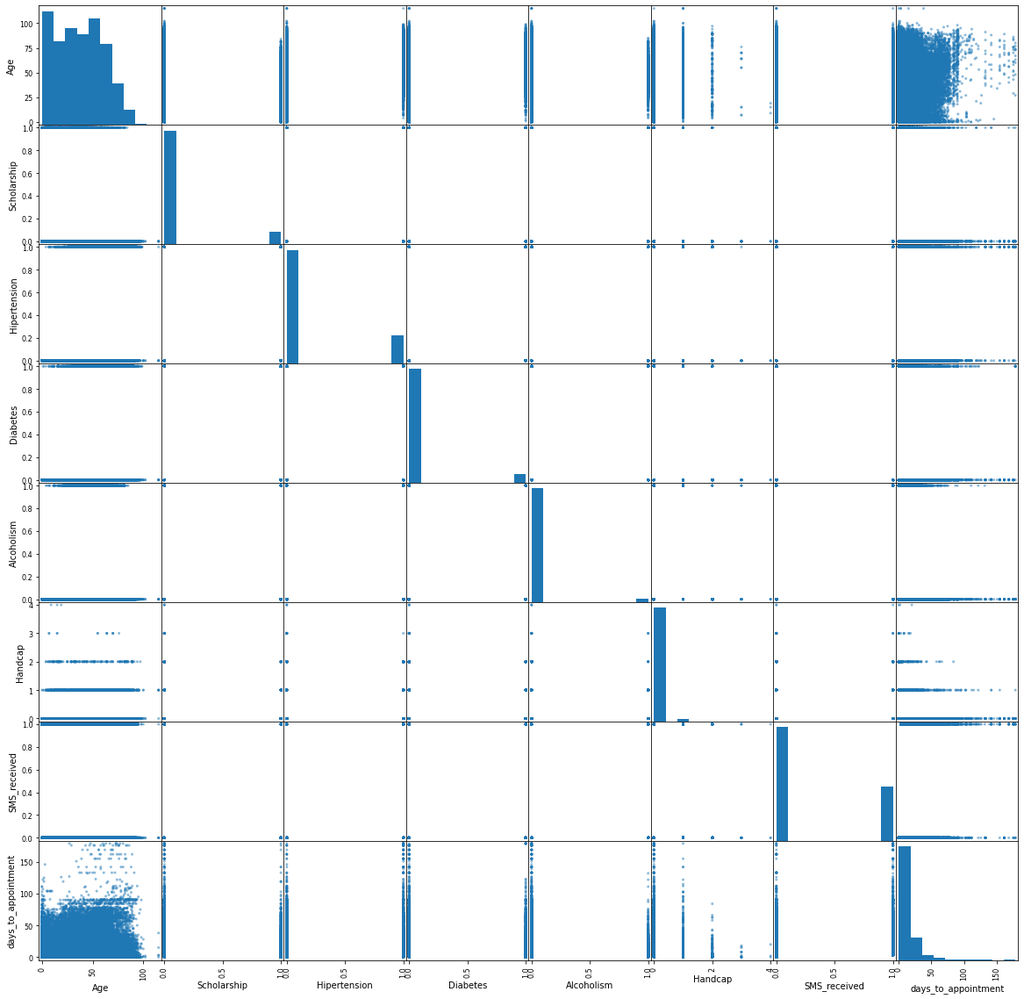

```python
pd.plotting.scatter_matrix(df, figsize=(20,20));
```

### Is gender a determining factor?

### Method 1

```python
df_show.Gender.value_counts()
```

```
F    57246
M    30962
Name: Gender, dtype: int64
```

```python
df_noshow.Gender.value_counts()
```

```
F    14594
M     7725
Name: Gender, dtype: int64
```

```python
tot_gender = df['Gender'].value_counts()
tot_gender
```

```
F    71840
M    38687
Name: Gender, dtype: int64
```

```python
gender_show = df_show.Gender.value_counts() / tot_gender * 100
gender_show
```

```
F    79.685412
M    80.032052
Name: Gender, dtype: float64
```

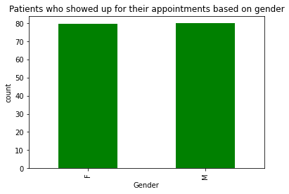

```python
# plotting patients who showed up more based on their gender
gender_show.plot(kind ='bar', color='g', title='Patients who showed up for their appointments based on gender', ylabel='count', xlabel='Gender')
```

```python
gender_noshow = df_noshow.Gender.value_counts() / tot_gender * 100
gender_noshow
```

```
F    20.314588
M    19.967948
Name: Gender, dtype: float64
```

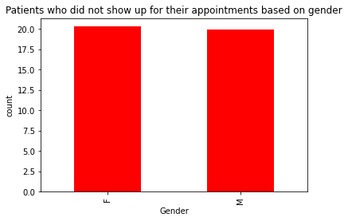

```python
# plotting patients who didn't show up more based on their gender
gender_noshow.plot(kind ='bar', color='r',  title='Patients who did not show up for their appointments based on gender', ylabel='count', xlabel='Gender')
```

### Method 2

```python
# grouping our data by gender to perform analysis.
gen_f = df.query('Gender == "F"')['No_show'].value_counts()
sum_f = np.sum(gen_f)
# getting the percentage distribution as it better helps in proportions
gen_f = df.query('Gender == "F"')['No_show'].value_counts() / sum_f * 100
gen_f
```

```
No     79.685412
Yes    20.314588
Name: No_show, dtype: float64
```

```python
# grouping our data by gender to perform analysis.
gen_m = df.query('Gender == "M"')['No_show'].value_counts()
sum_m = np.sum(gen_m)
# getting the percentage distribution as it better helps in proportions
gen_m = df.query('Gender == "M"')['No_show'].value_counts() / sum_m * 100
gen_m
```

```
No     80.032052
Yes    19.967948
Name: No_show, dtype: float64
```

```python
ind = np.arange(len(gen_f))  # the x locations for the groups
width = 0.2       # the width of the bars
```

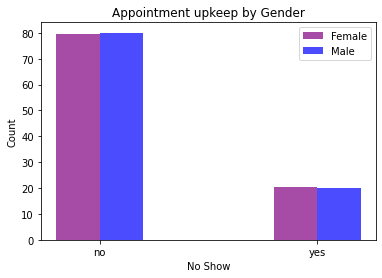

```python
red_bars = plt.bar(ind, gen_f, width, color='purple', alpha=.7, label='Female')
white_bars = plt.bar(ind + width, gen_m, width, color='b', alpha=.7, label='Male')
# title and labels
plt.ylabel('Count')
plt.xlabel('No Show')
plt.title('Appointment upkeep by Gender')
locations = ind + width / 2  # xtick locations
labels = ['no', 'yes']  # xtick labels
plt.xticks(locations, labels)

# legend
plt.legend()
```

#### from the above visual, we can tell that there is no strong correlation between the gender and whether or not one gender keeps to appointment than the other.

### Is age a determining factor?

```python
#Describing our data to create bins that will be used to group our data into four categories based on patient's age
df.describe()
```

|  | Age | Scholarship | Hipertension | Diabetes | Alcoholism | Handcap | SMS_received | days_to_appointment |
| --- | --- | --- | --- | --- | --- | --- | --- | --- |
| count | 110527.000000 | 110527.000000 | 110527.000000 | 110527.000000 | 110527.000000 | 110527.000000 | 110527.000000 | 110527 |
| mean | 37.088874 | 0.098266 | 0.197246 | 0.071865 | 0.030400 | 0.022248 | 0.321026 | 10 days 04:24:47.462791897 |
| std | 23.110205 | 0.297675 | 0.397921 | 0.258265 | 0.171686 | 0.161543 | 0.466873 | 15 days 06:07:01.236696805 |
| min | -1.000000 | 0.000000 | 0.000000 | 0.000000 | 0.000000 | 0.000000 | 0.000000 | 0 days 00:00:00 |
| 25% | 18.000000 | 0.000000 | 0.000000 | 0.000000 | 0.000000 | 0.000000 | 0.000000 | 0 days 00:00:00 |
| 50% | 37.000000 | 0.000000 | 0.000000 | 0.000000 | 0.000000 | 0.000000 | 0.000000 | 4 days 00:00:00 |
| 75% | 55.000000 | 0.000000 | 0.000000 | 0.000000 | 0.000000 | 0.000000 | 1.000000 | 15 days 00:00:00 |
| max | 115.000000 | 1.000000 | 1.000000 | 1.000000 | 1.000000 | 4.000000 | 1.000000 | 179 days 00:00:00 |

```python
# After describing, I realized that we have ages that are negative which is not possible, so I dropped it here
drop_ind = df.query('Age < 0')
df.drop(drop_ind.index, inplace=True)
```

```python
# creating age groups
bin = [0,18,37,55,115]
labels = ['Child', 'Young_Adult','Adult','Oldies']
df['Age_group'] = pd.cut(df['Age'], bin, labels=labels)
df.head()
```

|  | Gender | ScheduledDay | AppointmentDay | Age | Neighbourhood | Scholarship | Hipertension | Diabetes | Alcoholism | Handcap | SMS_received | No_show | days_to_appointment | Age_group |
| --- | --- | --- | --- | --- | --- | --- | --- | --- | --- | --- | --- | --- | --- | --- |
| 0 | F | 2016-04-29 | 2016-04-29 | 62 | JARDIM DA PENHA | 0 | 1 | 0 | 0 | 0 | 0 | No | 0 days | Oldies |
| 1 | M | 2016-04-29 | 2016-04-29 | 56 | JARDIM DA PENHA | 0 | 0 | 0 | 0 | 0 | 0 | No | 0 days | Oldies |
| 2 | F | 2016-04-29 | 2016-04-29 | 62 | MATA DA PRAIA | 0 | 0 | 0 | 0 | 0 | 0 | No | 0 days | Oldies |
| 3 | F | 2016-04-29 | 2016-04-29 | 8 | PONTAL DE CAMBURI | 0 | 0 | 0 | 0 | 0 | 0 | No | 0 days | Child |
| 4 | F | 2016-04-29 | 2016-04-29 | 56 | JARDIM DA PENHA | 0 | 1 | 1 | 0 | 0 | 0 | No | 0 days | Oldies |

```python
# grouping by age range
age = df.groupby(['Age_group'])['No_show'].value_counts().sort_values(ascending=False)
age
```

```
Age_group    No_show
Oldies       No         23201
Adult        No         21651
Young_Adult  No         20836
Child        No         19619
Young_Adult  Yes         6414
Child        Yes         5708
Adult        Yes         5255
Oldies       Yes         4303
Name: No_show, dtype: int64
```

```python
oldies = df.query('Age_group == "Oldies"')['No_show'].value_counts()
old_sum = np.sum(oldies)
oldies = oldies / old_sum * 100
oldies
```

```
No     84.355003
Yes    15.644997
Name: No_show, dtype: float64
```

```python
Adult = df.query('Age_group == "Adult"')['No_show'].value_counts()
adult_sum = np.sum(Adult)
Adult = Adult / adult_sum * 100
Adult
```

```
No     80.46904
Yes    19.53096
Name: No_show, dtype: float64
```

```python
Young_Adult = df.query('Age_group == "Young_Adult"')['No_show'].value_counts()
yun = np.sum(Young_Adult)
Young_Adult = Young_Adult / yun * 100
Young_Adult
```

```
No     76.462385
Yes    23.537615
Name: No_show, dtype: float64
```

```python
Child = df.query('Age_group == "Child"')['No_show'].value_counts()
child_sum = np.sum(Child)
Child = Child / child_sum * 100
Child
```

```
No     77.462787
Yes    22.537213
Name: No_show, dtype: float64
```

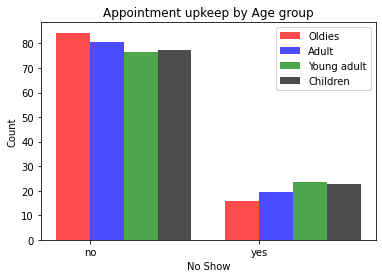

```python
Old = plt.bar(ind, oldies, width, color='r', alpha=.7, label='Oldies')
Adlt = plt.bar(ind + width, Adult, width, color='b', alpha=.7, label='Adult')
Yng_Adt = plt.bar(ind + 0.4, Young_Adult, width, color='g', alpha=.7, label='Young adult')
Children = plt.bar(ind + 0.6, Child, width, color='black', alpha=.7, label='Children')
# title and labels
plt.ylabel('Count')
plt.xlabel('No Show')
plt.title('Appointment upkeep by Age group')
locations = ind + width / 2  # xtick locations
labels = ['no', 'yes']  # xtick labels
plt.xticks(locations, labels)

# legendb
plt.legend()
```

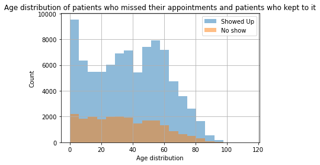

```python
df.query('No_show == "No"')['Age'].hist(alpha=0.5, bins=20, label='Showed Up')
df.query('No_show == "Yes"')['Age'].hist(alpha=0.5, bins=20, label='No show')
plt.xlabel('Age distribution')
plt.ylabel('Count')
plt.title('Age distribution of patients who missed their appointments and patients who kept to it')
plt.legend();
```

Young adults however, between the agest of 18 - 35 don't keep to appointments as much

### Does it matter if a patient is on scholarship or not?

```python
# defining a function to plot our bar charts for the rest of the columns

col_name = ['Scholarship','Hipertension','Diabetes','Alcoholism', 'Handcap', 'SMS_received']
def sub_plot(v0, v1, col):
    red_bars = plt.bar(ind, v0, width, color='g', alpha=.7, label='no')
    white_bars = plt.bar(ind + width, v1, width, color='r', alpha=.7, label='yes')
    # title and labels
    plt.ylabel('Count')
    plt.xlabel(f'{col}')
    plt.title(f'Appointment upkeep by {col}')
    locations = ind + width / 2  # xtick locations
    labels = ['no', 'yes']  # xtick labels
    plt.xticks(locations, labels)

    # legend
    plt.legend(title='No show')
```

```python
tot_scholarship = df['Scholarship'].value_counts()
tot_scholarship
```

```
0    99665
1    10861
Name: Scholarship, dtype: int64
```

```python
scholarship_show = df_show.Scholarship.value_counts() / tot_scholarship * 100
scholarship_show
```

```
0    80.193649
1    76.263696
Name: Scholarship, dtype: float64
```

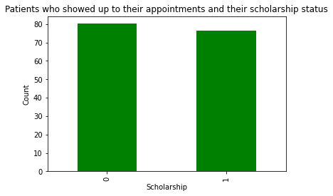

```python
scholarship_show.plot(kind ='bar', color='g', xlabel='Scholarship', ylabel='Count', title='Patients who showed up to their appointments and their scholarship status');
```

```python
scholarship_noshow = df_show.Scholarship.value_counts() / tot_scholarship * 100
scholarship_noshow
```

[output not shown]

[figure not shown]

```python
scholarship_noshow.plot(kind ='bar', color='r', xlabel='Scholarship', ylabel='count', title='Patients who did not show up to their appointments and their scholarship status');
```

```python
def compute_val(col):
    val_0 = df.query('No_show == "No"')[col].value_counts()
    val_0_sum = np.sum(val_0)
    val_0 =  val_0 / val_0_sum * 100

    val_1 = df.query('No_show == "Yes"')[col].value_counts()
    val_1_sum = np.sum(val_1)
    val_1 =  val_1 / val_1_sum * 100
    return val_0, val_1
```

```python
df.groupby(['No_show'])['Scholarship'].value_counts()
```

```
No_show  Scholarship
No       0              79924
         1               8283
Yes      0              19741
         1               2578
Name: Scholarship, dtype: int64
```

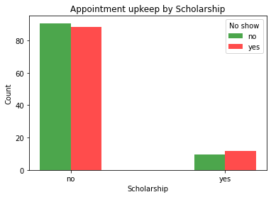

```python
val_0, val_1 = compute_val('Scholarship')
sub_plot(val_0, val_1, 'Scholarship')
```

I would say that from the analysis, being on scholarship does not determine if you would show up to your doctors appointment or not

### How does the underlying health status of the patient affect show up?

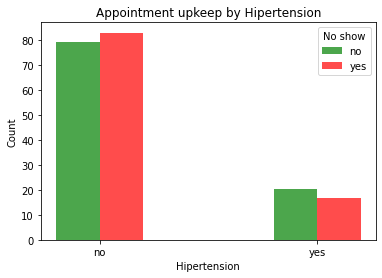

```python
val_0, val_1 = compute_val('Hipertension')
sub_plot(val_0, val_1, 'Hipertension')
```

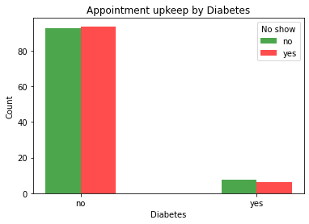

```python
val_0, val_1 = compute_val('Diabetes')
sub_plot(val_0, val_1, 'Diabetes')
```

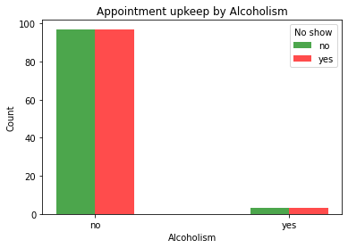

```python
val_0, val_1 = compute_val('Alcoholism')
sub_plot(val_0, val_1, 'Alcoholism')
```

```python
df['Handcap'].value_counts()
```

```
0    108285
1      2042
2       183
3        13
4         3
Name: Handcap, dtype: int64
```

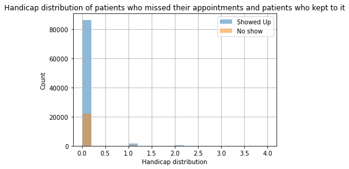

```python
df.query('No_show == "No"')['Handcap'].hist(alpha=0.5, bins=20, label='Showed Up')
df.query('No_show == "Yes"')['Handcap'].hist(alpha=0.5, bins=20, label='No show')
plt.xlabel('Handicap distribution')
plt.ylabel('Count')
plt.title('Handicap distribution of patients who missed their appointments and patients who kept to it')
plt.legend();
```

There was no details about the "Handcap" column and so I couldn't assume what the numbering meant

From the analysis on the health status of the patient, we can see that patients with an underlying health condition keep to appointments more than those who don't

### If recieving a reminder sms help a patient keep to appointments

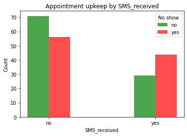

```python
val_0, val_1 = compute_val('SMS_received')
sub_plot(val_0, val_1, 'SMS_received')
```

### If the number of days between scheduling and the appointment days is a determining factor.

```python
# getting the mean number of days of people who show up and people who don't
days = df.groupby('No_show')['days_to_appointment'].mean()
days
```

```
No_show
No     8 days 18:06:51.151042434
Yes   15 days 19:58:38.060845020
Name: days_to_appointment, dtype: timedelta64[ns]
```

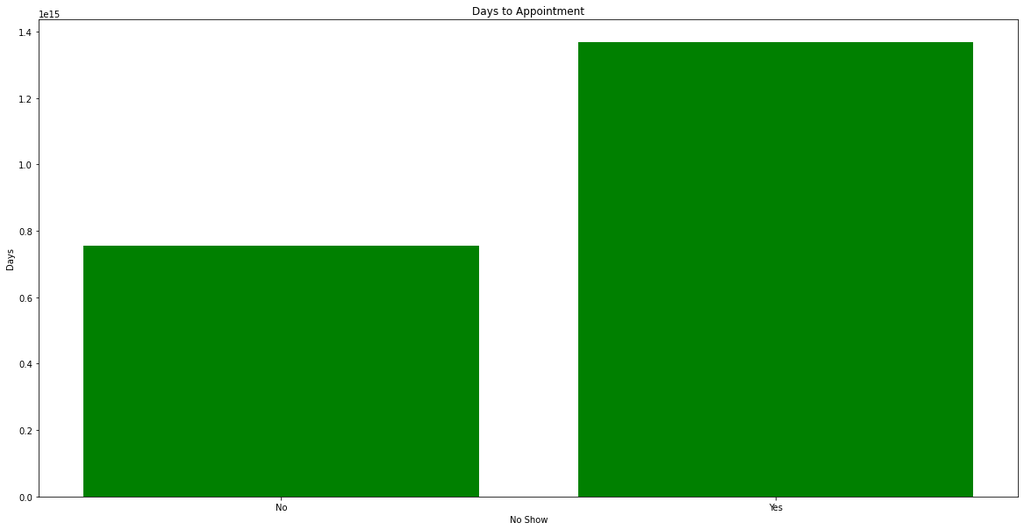

```python
fig, ax = plt.subplots(figsize=(20,10))
ax.bar(days.index, days, color='g')
ax.set(title='Days to Appointment', ylabel='Days', xlabel='No Show');
```

```python
# converting our days_to_appointment column to a datatype of float so that we can plot a histogram and see the age distribution wrt No show
df['days_to_appointment'] = df['days_to_appointment'].astype('timedelta64[D]')
df.info()
```

```
<class 'pandas.core.frame.DataFrame'>
Int64Index: 110526 entries, 0 to 110526
Data columns (total 14 columns):
 #   Column               Non-Null Count   Dtype
---  ------               --------------   -----
 0   Gender               110526 non-null  object
 1   ScheduledDay         110526 non-null  datetime64[ns]
 2   AppointmentDay       110526 non-null  datetime64[ns]
 3   Age                  110526 non-null  int64
 4   Neighbourhood        110526 non-null  object
 5   Scholarship          110526 non-null  int64
 6   Hipertension         110526 non-null  int64
 7   Diabetes             110526 non-null  int64
 8   Alcoholism           110526 non-null  int64
 9   Handcap              110526 non-null  int64
 10  SMS_received         110526 non-null  int64
 11  No_show              110526 non-null  object
 12  days_to_appointment  110526 non-null  float64
 13  Age_group            106987 non-null  category
dtypes: category(1), datetime64[ns](2), float64(1), int64(7), object(3)
memory usage: 11.9+ MB
```

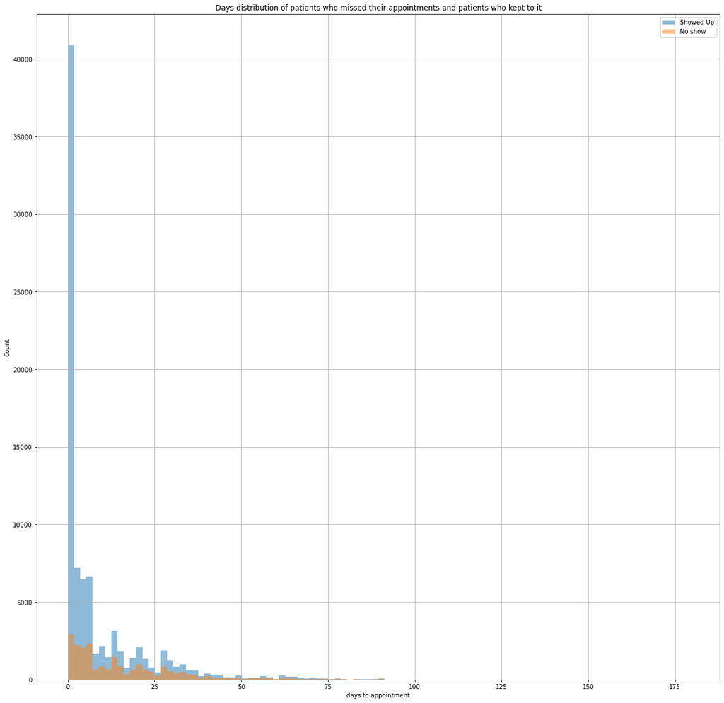

```python
df.query('No_show == "No"')['days_to_appointment'].hist(alpha=0.5, bins=100, label='Showed Up', figsize=(20,20))
df.query('No_show == "Yes"')['days_to_appointment'].hist(alpha=0.5, bins=100, label='No show', figsize=(20,20))
plt.xlabel('days to appointment')
plt.ylabel('Count')
plt.title('Days distribution of patients who missed their appointments and patients who kept to it')
plt.legend();
```

### Does the location of the hospital determine if a patient will show up?

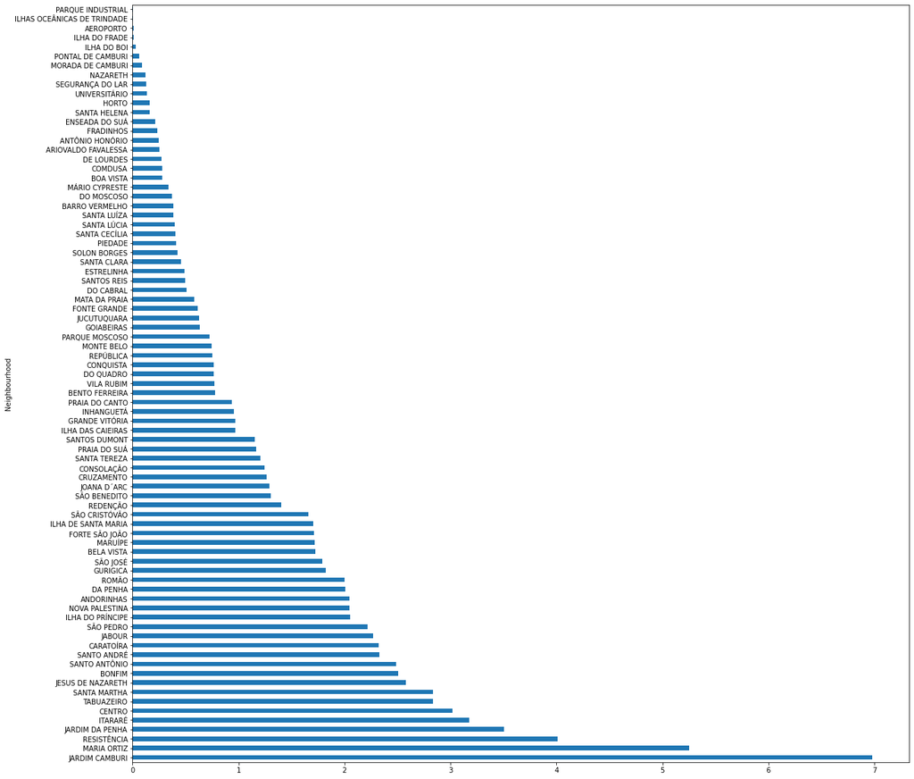

```python
# first we get the distribution of patients acroos the distinct neighbourhood
location_dist = df['Neighbourhood'].value_counts() / len(df) * 100
location_dist.sort_values(ascending=False).head(10)
location_dist.plot(kind='barh', figsize=(20,20), xlabel='Neighbourhood', ylabel='Count')
```

We can see that JARDIM CAMBURI has the highest number of patients scheduled for appointments followed by MARIA ORTIZ

```python
# in this neighbourhoods, what percentage of scheduled appointments keep to their appointments?
location_show = df.query('No_show == "No"')['Neighbourhood'].value_counts() / len(df) * 100
location_show = location_show.sort_values(ascending=False)
```

```python
# in this neighbourhoods, what percentage of scheduled appointments do not keep to their appointments?
location_noshow = df.query('No_show == "Yes"')['Neighbourhood'].value_counts() / len(df) * 100
location_noshow = location_noshow.sort_values(ascending=False)
```

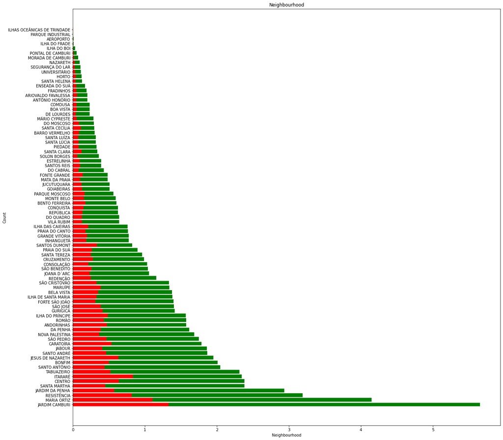

```python
fig, ax = plt.subplots(figsize=(20,20))
ax.barh(location_show.index, location_show, color='g')
ax.barh(location_noshow.index, location_noshow, color='r')
ax.set(title=f'Neighbourhood', ylabel='Count', xlabel='Neighbourhood');
```

In conclusion, factors that have shown to be important to determine if out patients will show up for their appointments are age, health status

## Conclusion

For easy visual and understanding of the no-show feature, I have color coded bars that signify Patients showing up as GREEN and patients who missed their appointments as RED

There were no missing data in our dataset, however, I believe a limitation to this anaysis was the time period. The data set contained records from November 2015 to June 2016, which is a short period of time to gain insights on important features that determine if a patient will keep to appointments